# Softening

Tarrik Quneibi

7/5/2021

All packages needed to run the code.

Importing the data and reading the fike to a variable.

This section cleans the data. Removes all NAs and empty cells. Converts all columns to their correct class. Combines the duplicate columns for hardness, calcium, and magnesium. Converts the calcium and magnesium columns to units of CaCO3. Removes all duplicate columns.

This chunk removes all extreme outliers from the pH and hardness data. anything aboce a pH of 14 and any hardness above 1000 mg/l CaCO3 are removed.

Organizes the full data set into seperate dataframes based on the loccation. Converts all date columns to date time class.

This plots the hardness of all basins over time.

[figure not shown]

[figure not shown]

This plots a boxplot of the calcium and magnesium concentrations separated by location.

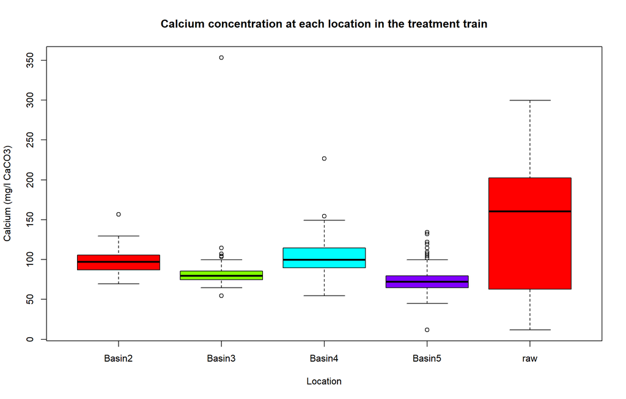

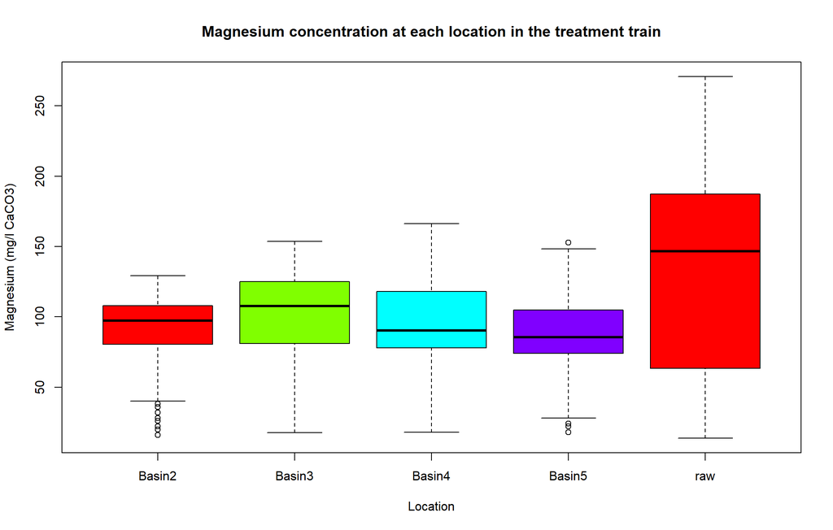

This plots a boxplot of the hardness at each location.

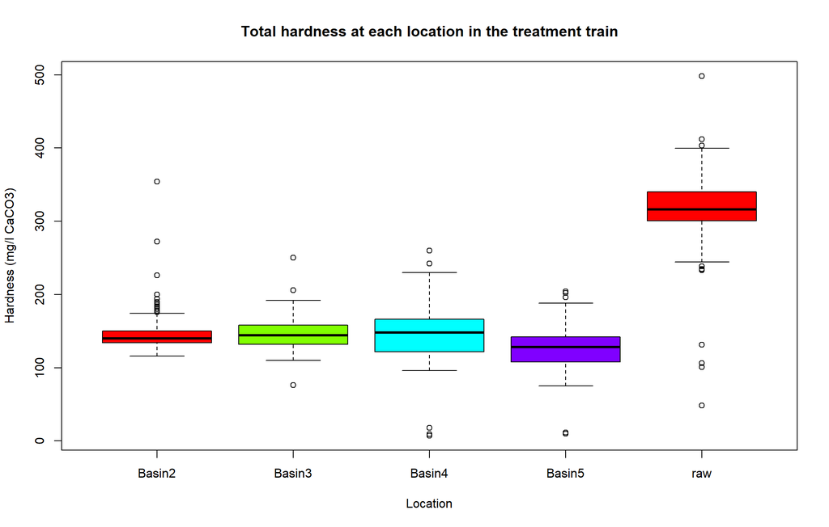

This plots all locations hardness over time.

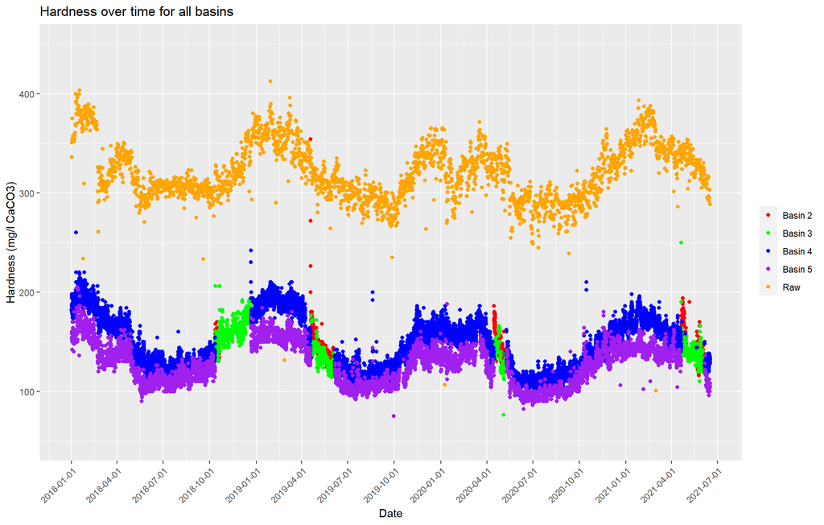

This plots the hardness removed by each basin over time. Also plots for each individual year.

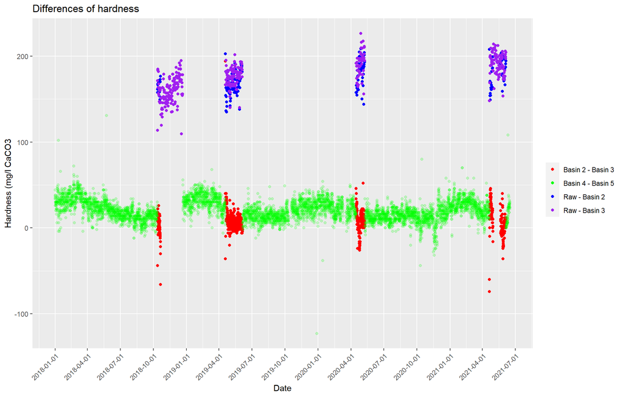

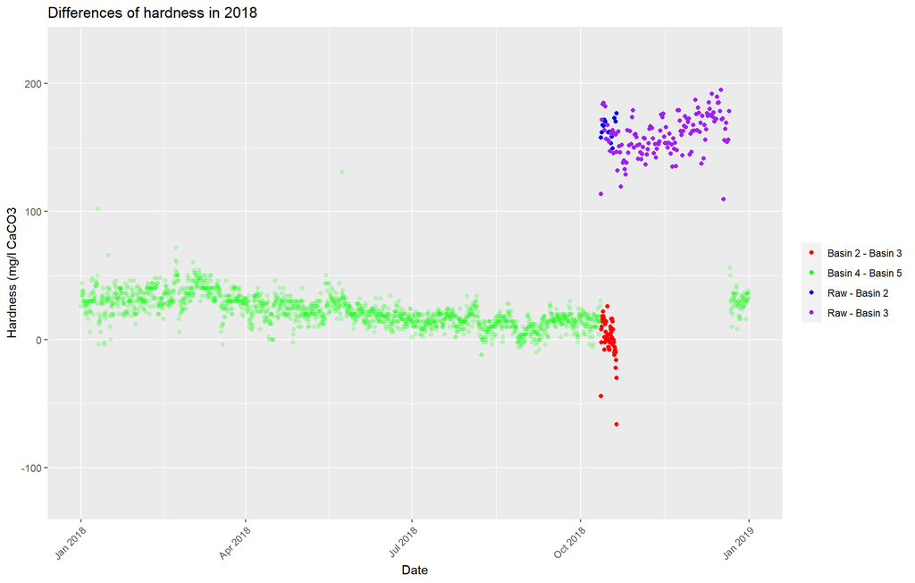

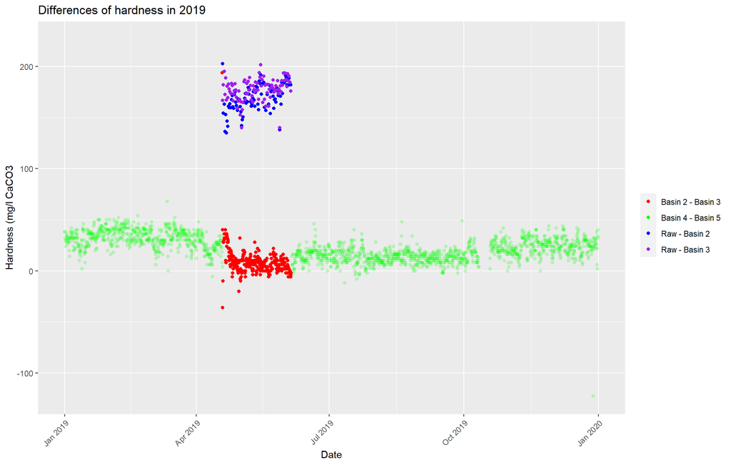

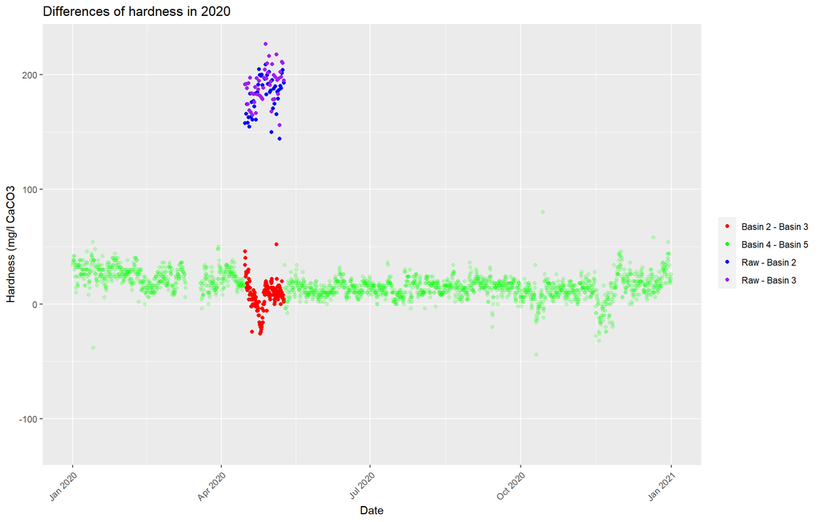

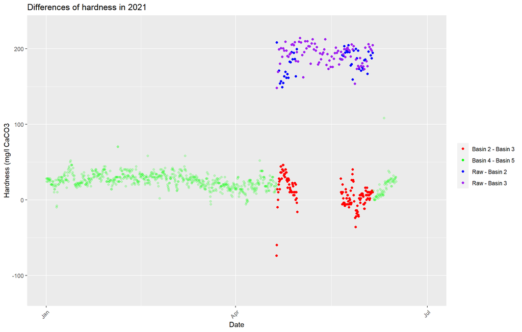

This plots the difference in hardness between basin 5 and 4, the alkalinity of both basins, the pH of both basins, and the temperature of the reservoir. Also plots for each individual year.

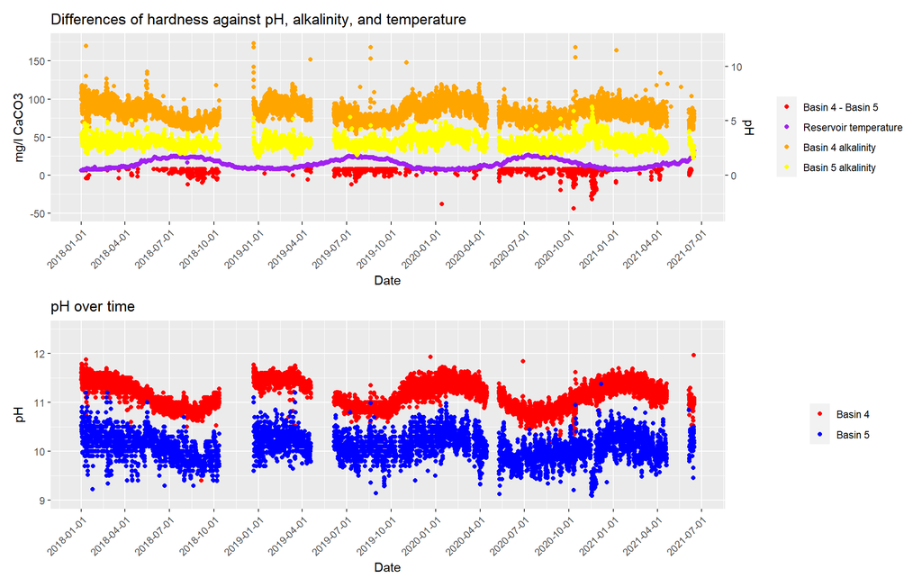

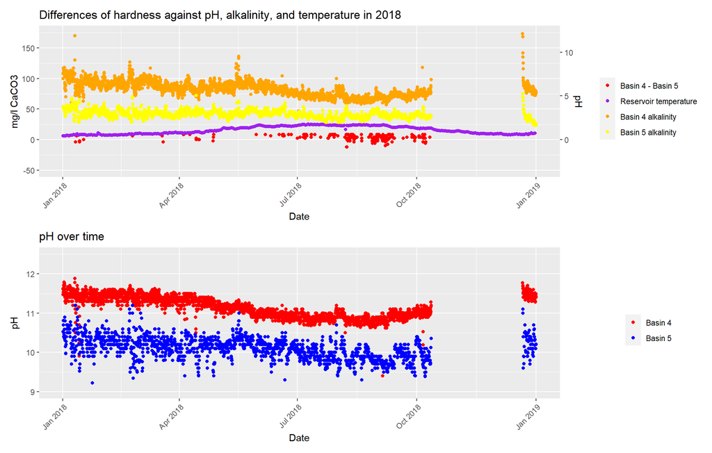

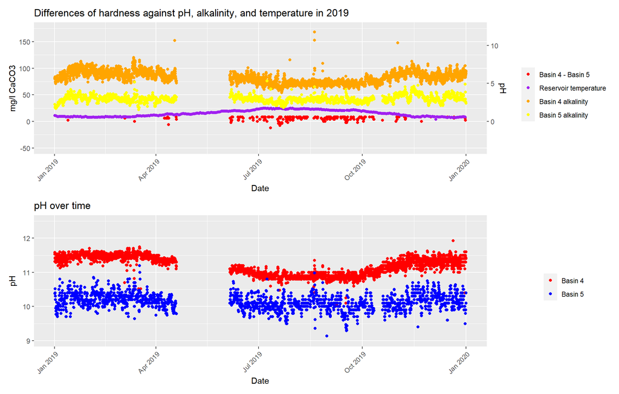

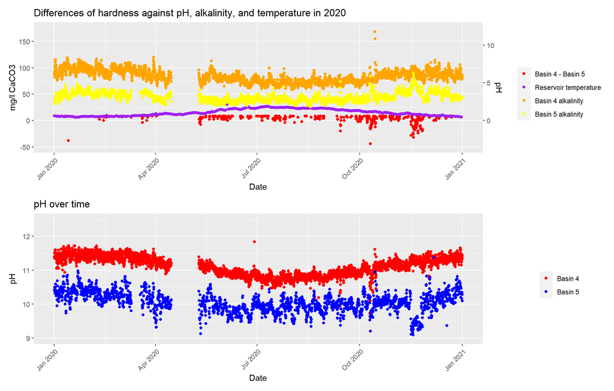

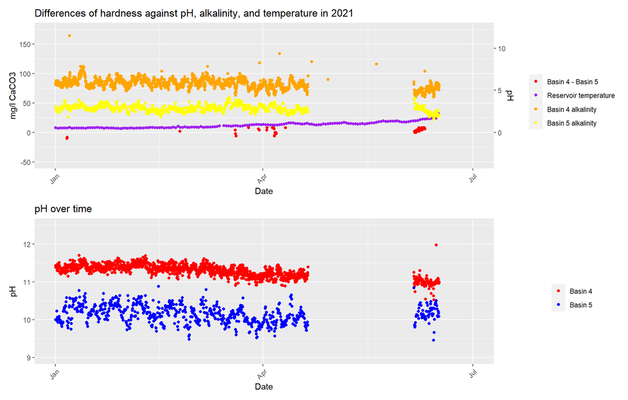

Plots the alkalinity of all basins over time.

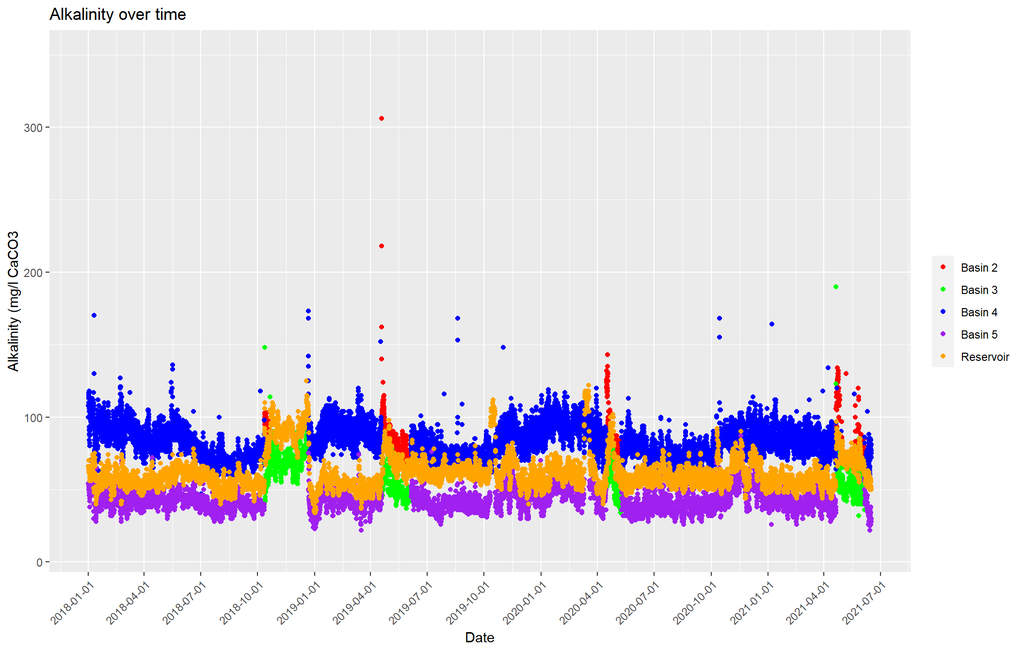

Plots the pH of allocations over time.

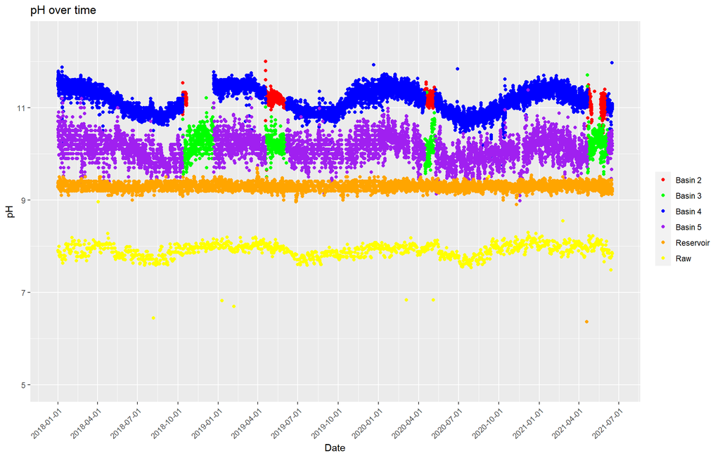